# Track-a-cohort: Figures

Updated: 2024-06-12

**Background**

Objective: Using shared resources via [BDO github](https://github.com/BDO-Science/track-a-cohort) from BOR, replicate figures and adjust to include dynamic data. See [Track a cohort_WR_plots.docx](https://github.com/BDO-Science/track-a-cohort/blob/main/Track%20a%20Cohort_WR_plots.docx) for figures requested. Also consider future additions including more interactive capabilities to certain graphs in form of Rmarkdown and/or shinyapp

Issues:

- For all figures – confirm method used to assign month to plots based on wDay.
- Update naming to improve accuracy
- update data sources

**Current figures**

## Figure 1. JPE Estimate

Susannah to prepare data for this figure.

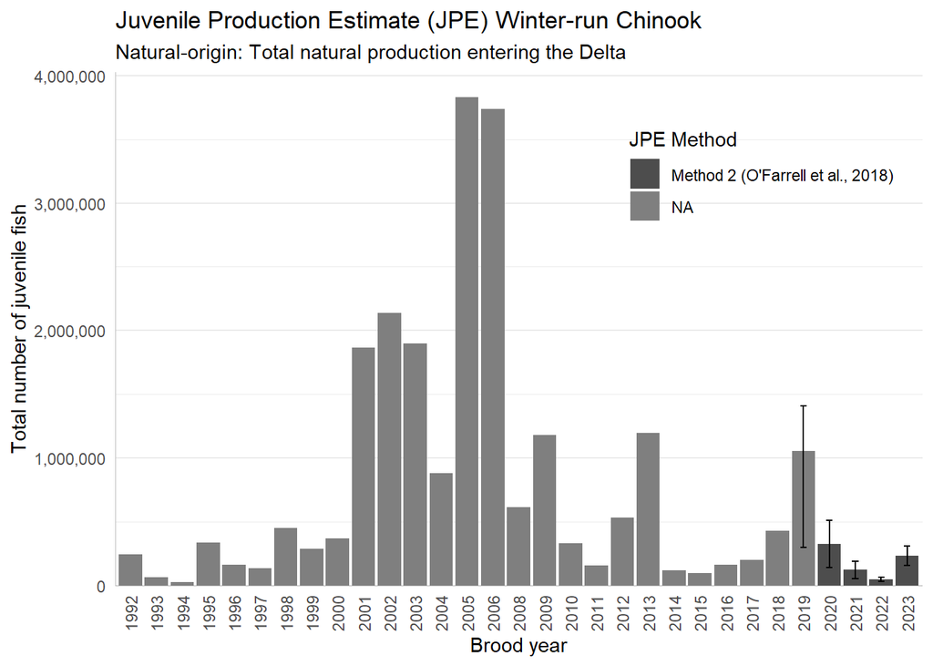

```r
jpe.url<- "https://www.cbr.washington.edu/sacramento/data/graphics/jpedata_Natural_1.txt"

jpe.raw <- data.table::fread(jpe.url)
jpe <- jpe.raw %>%
  mutate(method = str_replace(references_contributors, "Method 2 .*", "Method 2 (O'Farrell et al., 2018)")) %>%
    mutate(WY = brood_year + 1)



jpe_annual<- jpe %>%
  mutate(brood_year = as.factor(brood_year)) %>%
  ggplot( aes(x=brood_year, y=value, fill = method))+
  geom_bar(stat = "identity")+
  geom_errorbar(aes(ymin = lower_95_CI, ymax =upper_95_CI), width = 0.25)+
  labs(title = "Juvenile Production Estimate (JPE) Winter-run Chinook",
       subtitle = "Natural-origin: Total natural production entering the Delta",
       x = "Brood year",
       y = "Total number of juvenile fish",
       fill = "JPE Method")+
   scale_y_continuous( labels= scales::comma, expand = expansion(mult = c(0, 0.05))) +  # Set the lower limit of the y-axis to 0
  scale_fill_manual(values = c("NA" = "grey80", "Method 2 (O'Farrell et al., 2018)" = "grey30"))+
  theme_minimal() +
  theme(legend.position = c(0.8, 0.8),
        axis.text.x = element_text(angle = 90, vjust = .5, hjust = 1),
        axis.line = element_line(colour = "grey", linewidth = .25),
        panel.grid.minor.x = element_blank(),
         panel.grid.major.x  = element_blank())
jpe_annual
```

## Figure 2. STARS Delta Survival

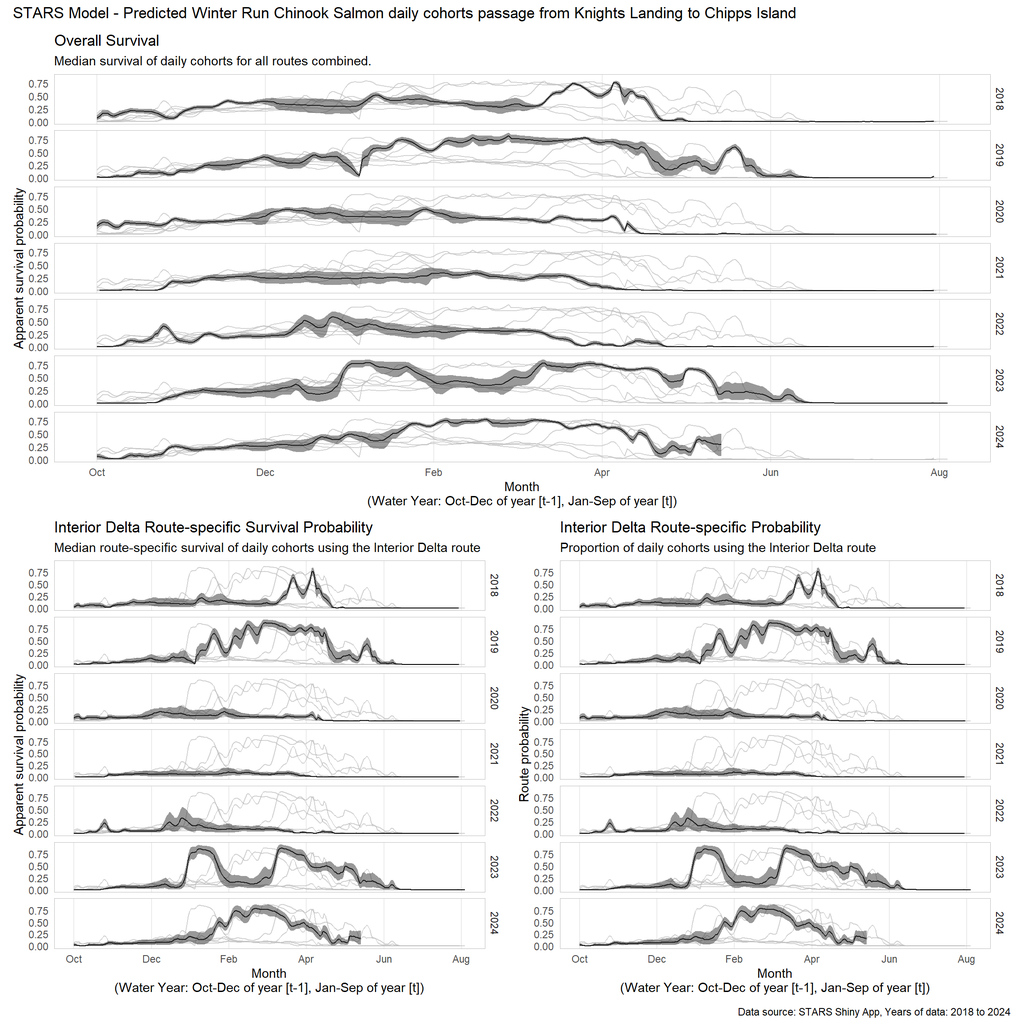

```r
p_stars <- p_stars_overall_survival / (p_stars_int_survival + p_stars_route_probability)


p_stars <- p_stars +
  plot_annotation(title = "STARS Model - Predicted Winter Run Chinook Salmon daily cohorts passage from Knights Landing to Chipps Island",
                  caption = "Data source: STARS Shiny App, Years of data: 2018 to 2024")

p_stars
```

Issues:

- Nick shared code to get latest STARs output.
  - To have real-time generated data for shiny, we’ll need to host in Linux server and have Susannah work her magic. Future update
- Determine best layout - possibly combine on one plot?
- Why are we highlighting one year compared to all years? Want to focus on current year compared to past years? Better way to approach?
- Include a shiny app to see hydrological year types? See `app.R` for basic shiny version
  - hoover label: best to just rename the datafile for geom_line() – using tooltip was not working. Look into how to drop gghighlight tooltip
  - update to using aes versus aes_string somehow and be able to plot x_var– see warning
  - plotly size

## Figure 3. Juvenile Production Estimate - Percent Loss

### Figure 3a. JPE percent loss - bar plot

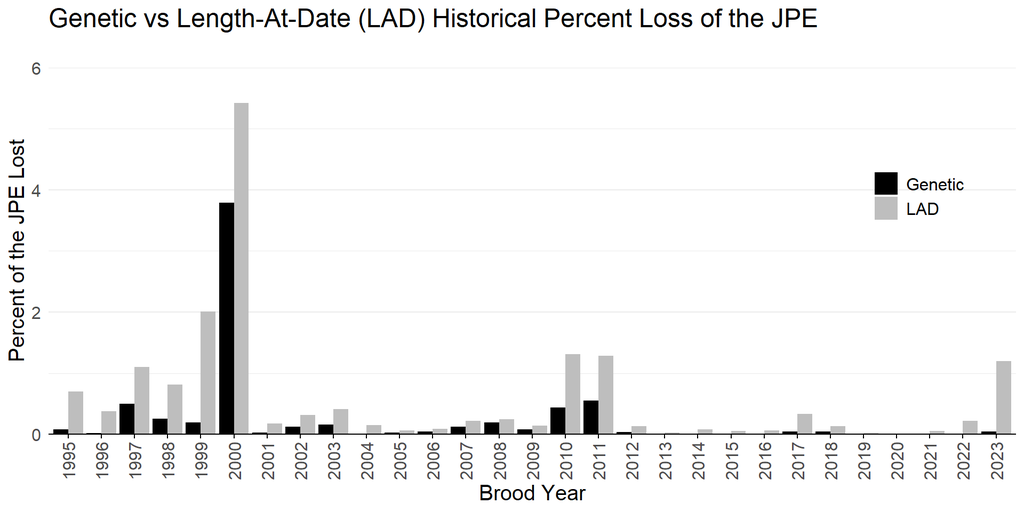

### Figure 3b. Cumulative percent Loss

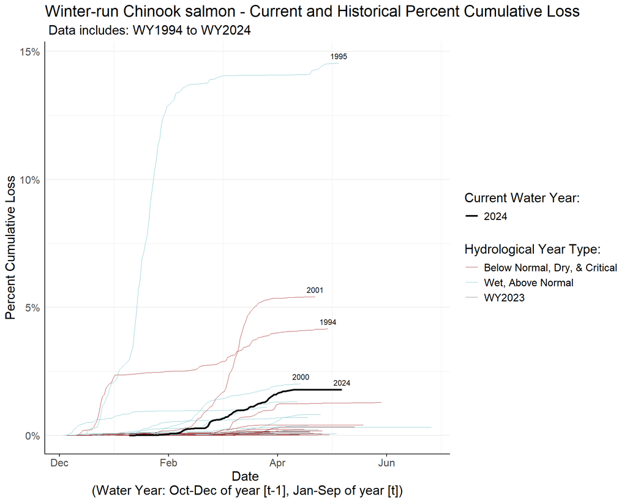

Issues: - Fig 3:

- updating naming and source files (work with Susannah)
- Fig3a :
  - uses 02_HistoricWRSalvageandLoss.R - Nick Bertrund’s code
  - `JPE_Genetic_Loss_Comparison.csv` is the current underlying flat file. Future update, pending decision on which QA/QC’d genetic data to use for comparison. Update with query string in time.

## Figure 4. Juvenile Production Estimate - Total Number Lost

### Figure 4a. JPE number loss - bar plot

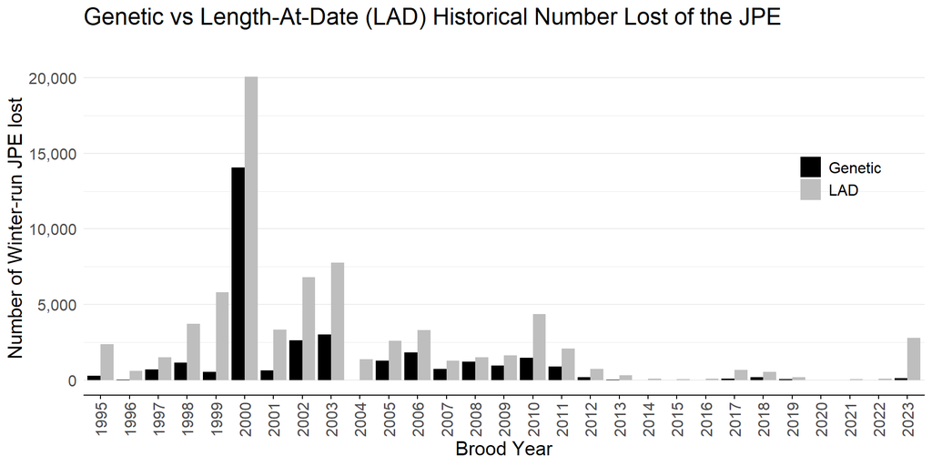

### Figure 4b. Cumulative number loss by hydrological season type and BiOp year

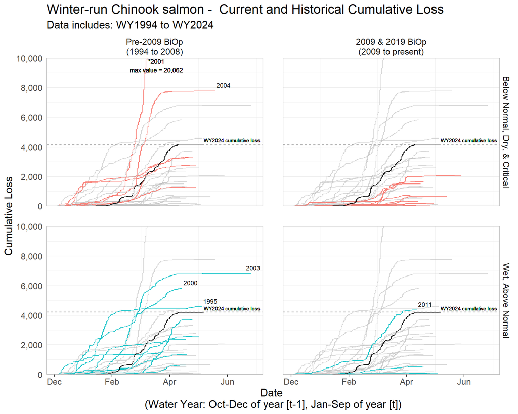

The grey lines are all years of cumulative loss, with the highlighted years indicating hydrological type, red for Below Normal, Dry, & Critical years, and blue for Wet, Above Normal hydrological yars. The black line represents current WY (2024) cumulative loss, with the dashed line indicating the max cumulative loss in current water year. Only years that are above the current years’ maximum cumulative loss are labelled with respective WY.

Questions:

- query from : https://www.cbr.washington.edu/sacramento/data/query_loss_detail.html with all years, species, and no LAD age restriction, but requires dna?
- filters to include winter for LAD OR winter for DNA, which also filters to include only chinook
  - could filter further to include only winter-run chinook for LAD and DNA diff or ~5700 to ~1700
- for some reason, the [url generated via query tool](https://www.cbr.washington.edu/sacramento/data/php/rpt/juv_loss_detail.php?sc=1&outputFormat=default&year=all&species=1%3Aall&dnaOnly=yes&age=no) for all chinook, all years, and no LAD age restriction, but requires dna, does not return nearly as many records as the url generated by BOR. Will use theres for now– look into why.
- Uses WYtype.csv – what is this data? Headers include: WY, Basin, Oct-Mar, Apr-Jul, WYsum, Index, Yr-type – Yr-type seems to be designating dry/wet year – where can this be sourced? This information will be hosted on SacPas updated website June 2024. The data is pulling from [CDEC](https://cdec.water.ca.gov/reportapp/javareports?name=WSIHIST). Working with static file until I can update.

## Figure 6. Cumulative loss by type with annual loss thresholds

- still working on setting threshold values

https://www.cbr.washington.edu/sacramento/workgroups/salmon_monitoring.html#:~:text=Natural%20Winter%2DRun%20Chinook%20Salmon%20Loss

Questions:

- get JPE data source updated
- pull salvage loss and filter to current year
- pull monthly daily triggers and update plot – where are these daily triggers being selected from?
- Where are the threshold values being calculated. The 2% single year JPE represents: “Loss of natural winter-run Chinook salmon, is 1.3% of the JPE on a three-year rolling average or 2.0% of the JPE in any single year.”
  - but where is the 100%, 75%, 50% coming from?
  - And, why is there a difference for LAD versus genetic data threshold values?
    - https://www.cbr.washington.edu/sacramento/workgroups/salmon_monitoring.html#:~:text=Single%2DYear%20Loss%20Thresholds%20(PA,Salmon%20(loss%3D%201.17%25%20of%20JPE)
- What is the significance of the -500 flow action?